# B. rapa Gene Networks

Julin N Maloof

5/17/2017

# Typical Julin Week

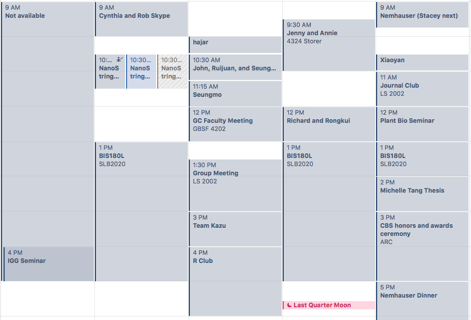

# Intro

- Goal: find genes & networks connected to *B. rapa* growth
- Rob Baker, Cynthia Weinig, Steve Welch, etc collected growth data on *B. rapa* RIL set in field setting.
- Growth functions were fitted for each line.
- We have gene expression for the same lines.
- Are there genes whose expression is associated with growth?

# Approach

- Use gene co-expression networks:
- For each growth trait, build a network of genes that have a similar pattern across the RILs
- In this case, look for association by mutual rank (MR)

# Mutual Rank

1. Build a correlation matrix of gene expression and trait values
2. For each gene or trait, rank its correlations with the other genes and traits. The gene with the highest correlation gets rank 1, etc.
3. For each gene x gene, gene x trait, or trait x trait pair, calculate the geometric average. This is the mutual rank.
4. Look at the network of genes (and traits) around each trait.
5. Determine significance by permutation.

# Starting data

| Line | CRr | CRHmax | CRInflection_DD | CRInflection_size | CRduration | CRSTP | Bra016271 | Bra035985 | Bra022069 |
| --- | --- | --- | --- | --- | --- | --- | --- | --- | --- |
| RIL_103 | 0 | 42.6 | 581.7 | 21.3 | 826.9 | 41.0 | 8.8 | 1.2 | -0.3 |
| RIL_115 | 0 | 21.8 | 629.7 | 10.9 | 888.8 | 20.7 | 8.8 | 1.0 | -0.7 |
| RIL_12 | 0 | 19.7 | 493.0 | 9.8 | 727.9 | 18.7 | 2.6 | 5.0 | 6.3 |
| RIL_124 | 0 | 42.2 | 720.1 | 21.1 | 992.4 | 39.9 | 8.8 | 5.3 | 5.7 |
| RIL_131 | 0 | 23.2 | 490.7 | 11.6 | 750.5 | 22.1 | 2.1 | 0.9 | -0.3 |
| RIL_136 | 0 | 27.0 | 562.6 | 13.5 | 854.5 | 25.4 | 8.9 | 5.1 | 6.1 |
| RIL_143 | 0 | 35.9 | 738.0 | 17.9 | 1013.8 | 33.7 | 3.2 | 5.1 | 5.9 |
| RIL_146 | 0 | 33.4 | 577.7 | 16.7 | 863.1 | 31.9 | 1.9 | 4.7 | 5.3 |
| RIL_147 | 0 | 34.4 | 656.1 | 17.2 | 910.9 | 32.9 | 2.9 | 5.1 | 6.0 |
| RIL_15 | 0 | 42.6 | 596.5 | 21.3 | 853.9 | 40.9 | 8.8 | 5.0 | 5.5 |

# Build correlation matrix

|  | CRr | CRHmax | CRInflection_DD | CRInflection_size | CRduration | CRSTP | Bra016271 | Bra035985 | Bra022069 |
| --- | --- | --- | --- | --- | --- | --- | --- | --- | --- |
| CRr | 1.00 | -0.48 | -0.52 | -0.48 | -0.67 | -0.46 | -0.03 | 0.23 | 0.29 |
| CRHmax | -0.48 | 1.00 | 0.79 | 1.00 | 0.79 | 1.00 | 0.12 | -0.06 | -0.08 |
| CRInflection_DD | -0.52 | 0.79 | 1.00 | 0.79 | 0.97 | 0.78 | -0.01 | -0.11 | -0.13 |
| CRInflection_size | -0.48 | 1.00 | 0.79 | 1.00 | 0.79 | 1.00 | 0.12 | -0.06 | -0.08 |
| CRduration | -0.67 | 0.79 | 0.97 | 0.79 | 1.00 | 0.78 | 0.00 | -0.13 | -0.17 |
| CRSTP | -0.46 | 1.00 | 0.78 | 1.00 | 0.78 | 1.00 | 0.12 | -0.06 | -0.08 |
| Bra016271 | -0.03 | 0.12 | -0.01 | 0.12 | 0.00 | 0.12 | 1.00 | -0.01 | 0.00 |
| Bra035985 | 0.23 | -0.06 | -0.11 | -0.06 | -0.13 | -0.06 | -0.01 | 1.00 | 0.96 |
| Bra022069 | 0.29 | -0.08 | -0.13 | -0.08 | -0.17 | -0.08 | 0.00 | 0.96 | 1.00 |

# Calculate mutual ranks

|  | CRr | CRHmax | CRInflection_DD | CRInflection_size | CRduration | CRSTP | Bra016271 | Bra035985 | Bra022069 | Bra040221 |
| --- | --- | --- | --- | --- | --- | --- | --- | --- | --- | --- |
| CRr | 1 | 174 | 65 | 175 | 4 | 228 | 8279 | 1503 | 1001 | 8021 |
| CRHmax | 174 | 1 | 4 | 2 | 4 | 2 | 3766 | 7129 | 5966 | 2466 |
| CRInflection_DD | 65 | 4 | 1 | 3 | 2 | 4 | 9562 | 4696 | 3948 | 9137 |
| CRInflection_size | 175 | 2 | 3 | 1 | 4 | 3 | 3765 | 7130 | 5966 | 2467 |
| CRduration | 4 | 4 | 2 | 4 | 1 | 5 | 10004 | 3938 | 2966 | 8711 |
| CRSTP | 228 | 2 | 4 | 3 | 5 | 1 | 3524 | 7127 | 5974 | 2314 |
| Bra016271 | 8279 | 3766 | 9562 | 3765 | 10004 | 3524 | 1 | 9498 | 9733 | 4967 |
| Bra035985 | 1503 | 7129 | 4696 | 7130 | 3938 | 7127 | 9498 | 1 | 5 | 5670 |
| Bra022069 | 1001 | 5966 | 3948 | 5966 | 2966 | 5974 | 9733 | 5 | 1 | 3558 |
| Bra040221 | 8021 | 2466 | 9137 | 2467 | 8711 | 2314 | 4967 | 5670 | 3558 | 1 |

# What do we get?

# MR < 20

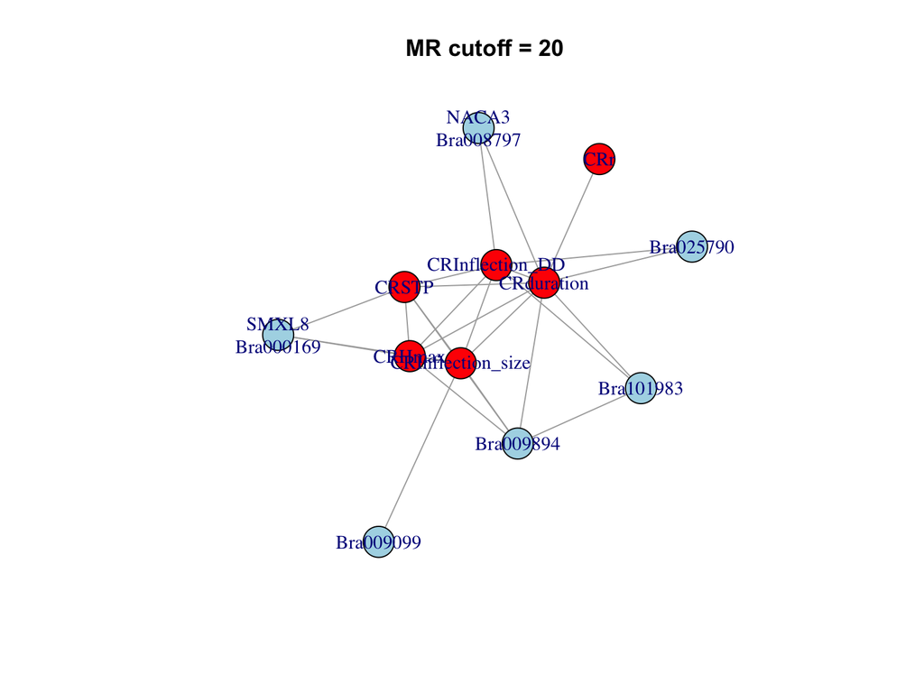

# MR < 30

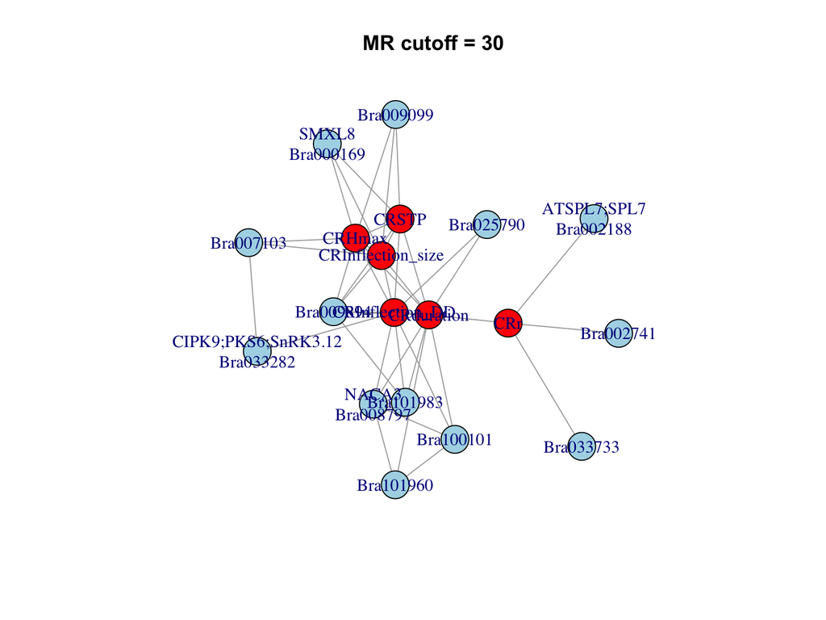

# MR < 50

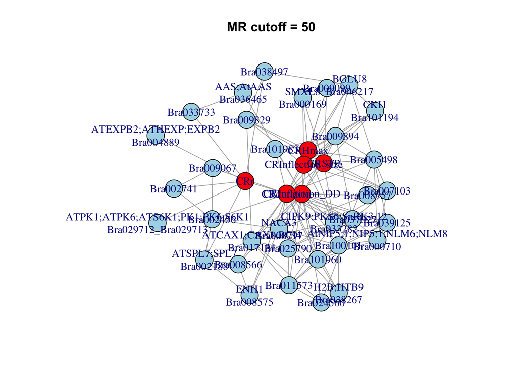

# Significance thresholds

- Randomize traits relative to gene expression
- Make a graph, count # of connections
- Repeat 100 times
- Calculate 95th percentile # of connections
- You would expect fewer than this number 95% of the time in random data

# Significance thresholds

| *MR Threshold* | *95th percentile expectation (CR)* | *Observed (CR)*] |
| --- | --- | --- |
| 20 | 1 | 6 |
| 30 | 3 | 13 |
| 50 | 9 | 33 |
| 80 | 24 | 73 |

So the networks are enriched for “real” connections

# Candidates from CR condition

- NACA3: Nascent polypeptide-associated complex gene (MR10+)
- SMXL8: Involved in strigolactone-regulated growth (MR20+)
- CIPK9: CBL interacting protein kinase 9. K+ homeostasis (MR30+)
- ATEXPB2: Beta Expansin. (MR50+)
- (And in UN: MES10, Methyl Jasmonate Esterase at MR10+)

# Next Steps

- Are any of these under QTL peaks for growth traits?
- Compare with WGCNA